# Regression

Veera_Namana

9/16/2019

#Simple Linear Regression Model

#Clearing previously assigned variables

```r
rm(list = ls(all = TRUE))
```

#Setting working directory and reading the data

```r
getwd()
```

```
## [1] "/Users/tejaswinamana/Desktop/INSOFE"
```

```r
setwd("/Users/tejaswinamana/downloads/practice/")
getwd()
```

```
## [1] "/Users/tejaswinamana/Downloads/practice"
```

```r
cars_data = read.csv("Toyota_SimpleReg.csv", header = T)
```

#Exploratory data analysis

```r
#Display the column names
colnames(cars_data)
```

```
## [1] "Id"        "Model"     "Price"     "Age_06_15"
```

```r
#Structure of the data
str(cars_data)
```

```
## 'data.frame':    1436 obs. of  4 variables:
##  $ Id       : int  1 2 3 4 5 6 7 8 9 10 ...
##  $ Model    : Factor w/ 372 levels "\xa0TOYOTA Corolla 1.3 16V HATCHB G6 2/3-Doors",..: 332 332 67 332 331 331 64 326 62 59 ...
##  $ Price    : int  13500 13750 13950 14950 13750 12950 16900 18600 21500 12950 ...
##  $ Age_06_15: int  57 57 58 60 64 66 61 64 61 57 ...
```

```r
nrow(cars_data)   #number of rows in the dataset
```

```
## [1] 1436
```

```r
ncol(cars_data)   #number of columns in the dataset
```

```
## [1] 4
```

```r
summary(cars_data)  #Summary of the dataset
```

```
##        Id
##  Min.   :   1.0
##  1st Qu.: 361.8
##  Median : 721.5
##  Mean   : 721.6
##  3rd Qu.:1081.2
##  Max.   :1442.0
##
##                                                  Model
##  TOYOTA Corolla 1.6 16V HATCHB LINEA TERRA 2/3-Doors: 107
##  TOYOTA Corolla 1.3 16V HATCHB LINEA TERRA 2/3-Doors:  83
##  TOYOTA Corolla 1.6 16V LIFTB LINEA LUNA 4/5-Doors  :  79
##  TOYOTA Corolla 1.6 16V LIFTB LINEA TERRA 4/5-Doors :  70
##  TOYOTA Corolla 1.6 16V SEDAN LINEA TERRA 4/5-Doors :  43
##  TOYOTA Corolla 1.4 16V VVT I HATCHB TERRA 2/3-Doors:  42
##  (Other)                                            :1012
##      Price         Age_06_15
##  Min.   : 4350   Min.   : 35.00
##  1st Qu.: 8450   1st Qu.: 78.00
##  Median : 9900   Median : 95.00
##  Mean   :10731   Mean   : 89.95
##  3rd Qu.:11950   3rd Qu.:104.00
##  Max.   :32500   Max.   :114.00
##
```

#Look for missing values

```r
sum(is.na(cars_data))
```

```
## [1] 0
```

#There are no na values in the dataset

#Dropping unnecessary columns

```r
drop_cols <- c("Id","Model")
cars_data[,drop_cols] <- NULL
```

#Checking the structure again after dropping variables

```r
str(cars_data)
```

```
## 'data.frame':    1436 obs. of  2 variables:
##  $ Price    : int  13500 13750 13950 14950 13750 12950 16900 18600 21500 12950 ...
##  $ Age_06_15: int  57 57 58 60 64 66 61 64 61 57 ...
```

#Renaming Age column

```r
#colnames(cars_data)[colnames(cars_data)] == "Age_06_15" <- "Age"

####or#######

colnames(cars_data)[2] <- "Age"
```

#Scatter Plot - plotting dependent and independent variable

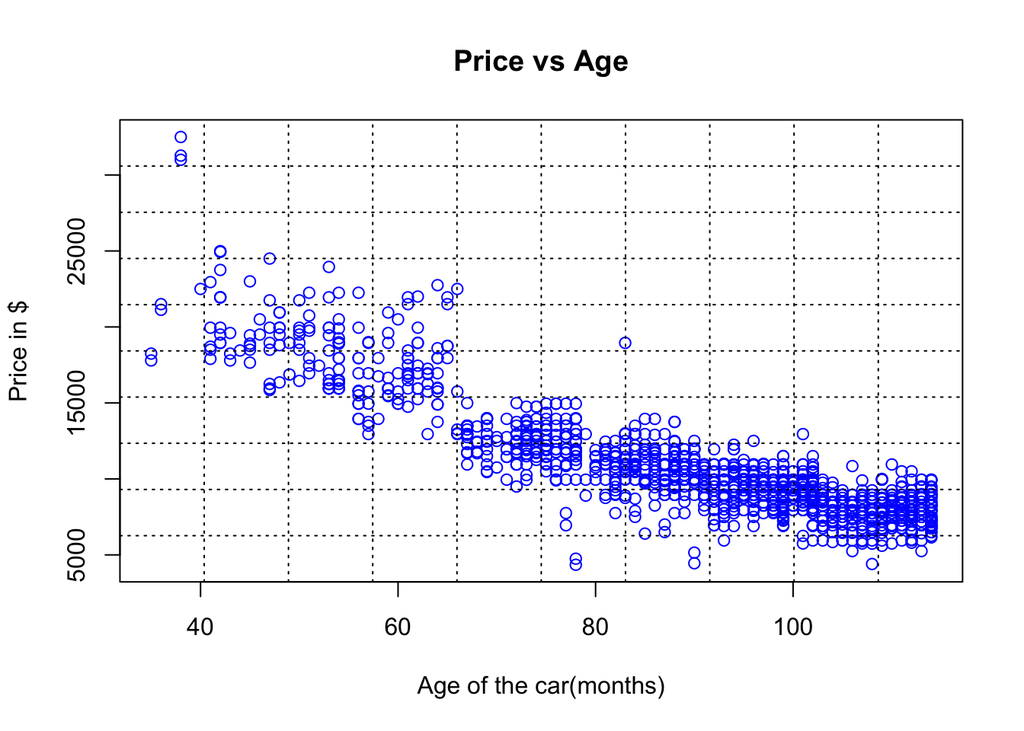

```r
plot(cars_data$Age,cars_data$Price,
     main = "Price vs Age",
     xlab = "Age of the car(months)",
     ylab = "Price in $",
     col = "blue")

grid(10,10, lwd = 1, col = "Black")
```

#The graph represents Price and age are negaively correlated i.e., if one increases the other decreases

#Covariance between the attributes

```r
cov(cars_data$Price,cars_data$Age)
```

```
## [1] -59136.11
```

#The covariance represents Price and Age are not moving together (due to negative covariance)

#Correlation between the attributes

```r
cor_data = cor(cars_data)

cor_data
```

```
##            Price        Age
## Price  1.0000000 -0.8765905
## Age   -0.8765905  1.0000000
```

#Price and Age are strong negatively correlated(-0.876)

#Corrplot - Graphical representaton of correlation

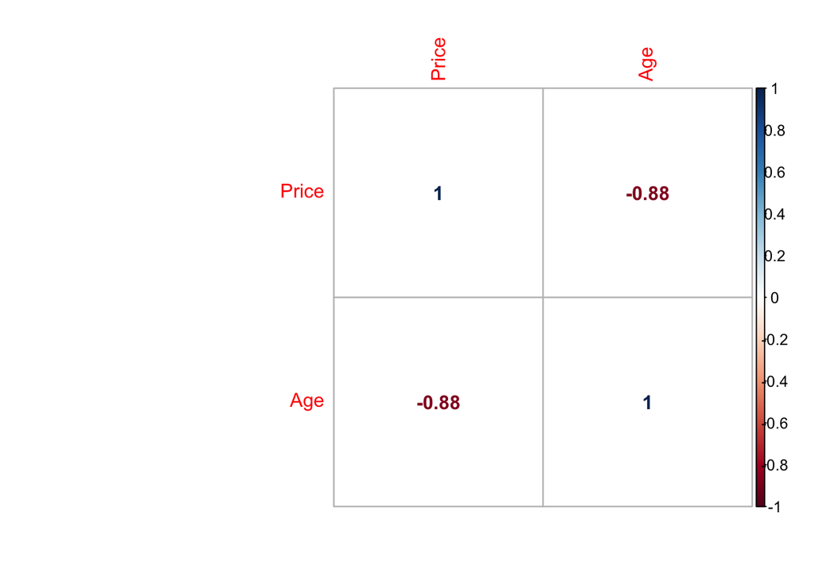

```r
library(corrplot)
corrplot(cor_data, method = "number") #displays correlation coefficient in numbers
```

#Model Building

#Train -Test Split(70:30) - Split the data into Train and Test sets

```r
set.seed(123)
rows = seq(1,nrow(cars_data),1)
trainRows = sample(rows,(70*nrow(cars_data))/100)

cars_train = cars_data[trainRows,]
cars_test = cars_data[-trainRows,]

nrow(cars_train)
```

```
## [1] 1005
```

```r
nrow(cars_test)
```

```
## [1] 431
```

#Building the linear regression model

```r
LinReg = lm(Price ~ Age, data = cars_train)
```

#Model Summary

```r
summary(LinReg)
```

```
##
## Call:
## lm(formula = Price ~ Age, data = cars_train)
##
## Residuals:
##     Min      1Q  Median      3Q     Max
## -7970.9  -941.0    -9.3   860.5 11751.8
##
## Coefficients:
##              Estimate Std. Error t value Pr(>|t|)
## (Intercept) 25985.348    266.910   97.36   <2e-16 ***
## Age          -170.057      2.905  -58.53   <2e-16 ***
## ---
## Signif. codes:  0 '***' 0.001 '**' 0.01 '*' 0.05 '.' 0.1 ' ' 1
##
## Residual standard error: 1689 on 1003 degrees of freedom
## Multiple R-squared:  0.7735, Adjusted R-squared:  0.7733
## F-statistic:  3426 on 1 and 1003 DF,  p-value: < 2.2e-16
```

#Plot the datapoints and line of best fit

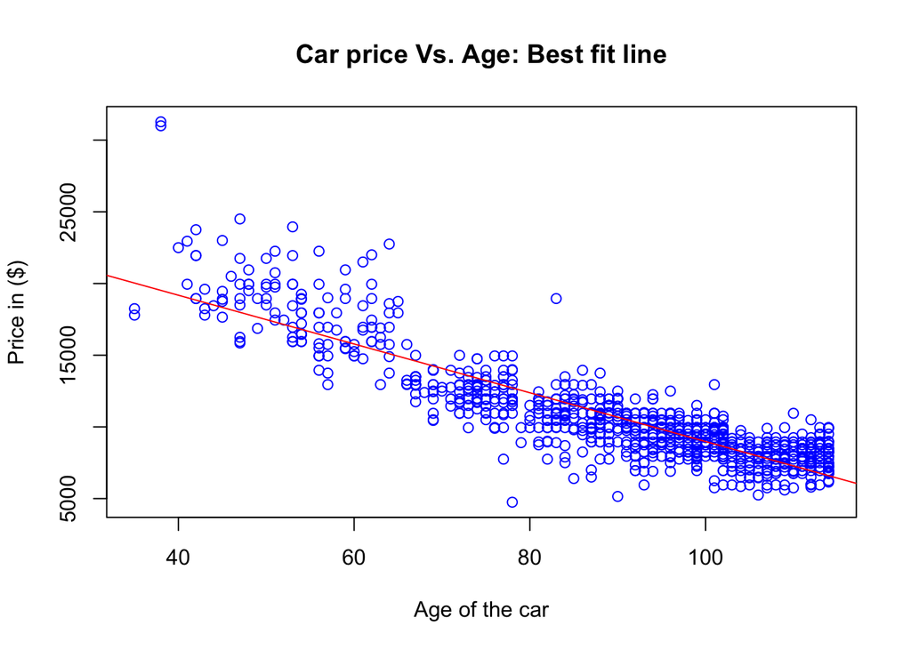

```r
plot(cars_train$Age, cars_train$Price,
     xlab = "Age of the car",
     ylab = "Price in ($)",
     main = "Car price Vs. Age: Best fit line", col = "blue")

abline(LinReg,col = "Red", lwd =  1)  #The function adds straigt line to a plot
```

#To extract the coeffcients

```r
LinReg$coefficients
```

```
## (Intercept)         Age
##   25985.348    -170.057
```

#To extract residuals

```r
head(LinReg$residuals)
```

```
##         415         463         179         526         195         938
##  -970.61994 -1630.79083  3107.04461 -1110.44905    18.92436   310.46234
```

#To extract fitted values

```r
head(LinReg$fitted.values)
```

```
##       415       463       179       526       195       938
## 11870.620 12380.791 18842.955 11360.449 13231.076  8639.538
```

#Validating Linear regression assumptions

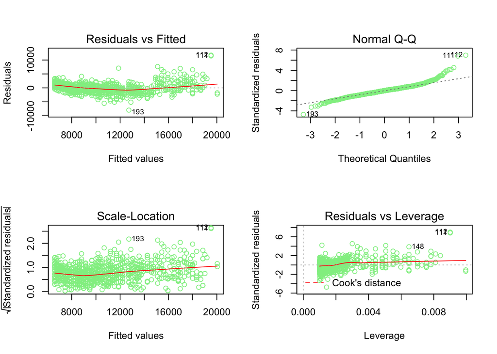

```r
par(mfrow = c(2,2))                         #Par helps us to set the graphical parameters
plot(LinReg, lwd=1, col = 'light green')    #Check for validity of linear regression assumptions
```

#Plot residuals vs fitted values #Helps us to visualize how the residuals are distributed in relation to the fitted values

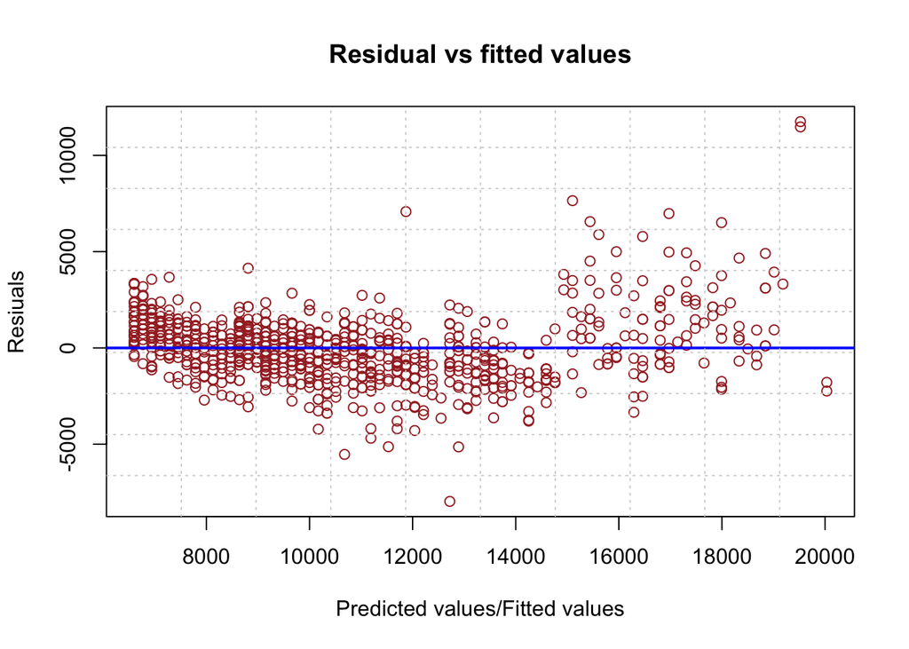

```r
plot(LinReg$fitted.values, LinReg$residuals, main = "Residual vs fitted values",
     col = "brown", lwd = 1,
     xlab = "Predicted values/Fitted values",
     ylab = "Resiuals")

abline(h = 0,col = 'blue',lwd = 2)
grid(10,10,lwd=1)
```

#Predict on Test Data

```r
test_prediction = predict(LinReg,cars_test)    #Fitted values
test_actual = cars_data$Price                  #Actual values
```

###Performance metrics #MAE - Mean Absolute Error

```r
mae <- function(actual, predicted){
  error = actual-predicted
  mean(abs(error))
}

mae(test_actual,test_prediction)
```

```
## [1] 3404.189
```

#MSE - Mean Squared Error

```r
mse <- function(actual, predicted){
  error = actual - predicted
  mean(error^2)
}

mse(test_actual,test_prediction)
```

```
## [1] 18952908
```

#RMSE - Root Mean Squared Error

```r
rmse <- function(actual, predicted){
  error = actual - predicted
  sqrt(mean(error^2))
}

rmse(test_actual,test_prediction)
```

```
## [1] 4353.494
```

```r
library(DMwR)
regr.eval(cars_train$Price, LinReg$fitted.values)
```

```
##          mae          mse         rmse         mape
## 1.216922e+03 2.845463e+06 1.686850e+03 1.186451e-01
```

```r
regr.eval(test_actual,test_prediction)
```

```
##          mae          mse         rmse         mape
## 3.404189e+03 1.895291e+07 4.353494e+03 3.291573e-01
```